# README

**REQUIRED** — A Zendesk Account and API Token are required to use this module.

Follow the steps below to learn how to generate a token and enter it into the Zendesk Unsolved Tickets module.

## Steps to finish setup

- Sign into Zendesk
- Create an API Token
- Enter the token into the Zendesk Unsolved Tickets module

## What is an API Token and why do I need it?

> An application programming interface key/token (API key/token) is a code passed in by computer programs calling an application programming interface (API) to identify the calling program, its developer, or its user to the Web site.

An API Token allows the Zendesk Unsolved Tickets module access to your Zendesk account data without the need for a username/password.

## Logging into Zendesk

```
https://{your_domain}.Zendesk.com/agent/admin/api/settings/tokens
```

- Change the `{your_domain}` value in the above link to your Zendesk subdomain, then open the link in your web browser
- You may be asked to enter your sign in details
- Follow the on screen steps to sign in
- After signing in you will be redirected to a page that looks like the following:

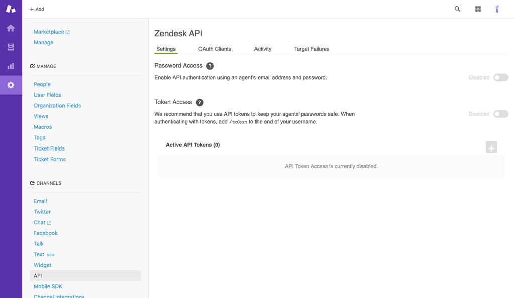

## Creating an API Token

- If your `Token Access` section is disabled click the switch to enable it

[figure not shown]

- Once it’s enabled click the `+` button to add a new API Token.

[figure not shown]

- In the form that appears enter `Infinity Dashboard Module` in the `API Token Description` field.

[figure not shown]

- Click the `Copy` button to copy the API Token
- Click the `Save` button to continue to the next section

## Entering your API Token into Infinity Dashboard

- Open Infinity Dashboard
- Click on the ‘Module Config’ item in the sidebar
- Locate the Zendesk Unsolved Tickets module you want to configure
- Click the Pencil icon to open the module configuration
- Locate the **Email** config option
- Click the **Your Zendesk Email Address** label to edit the value
- Enter your Zendesk Sign In Email into this field
- Locate the **API Token** config option
- Click the **Your API Token from Zendesk** label to edit the value
- Paste the copied API Token into the field
- Click the `Done` button

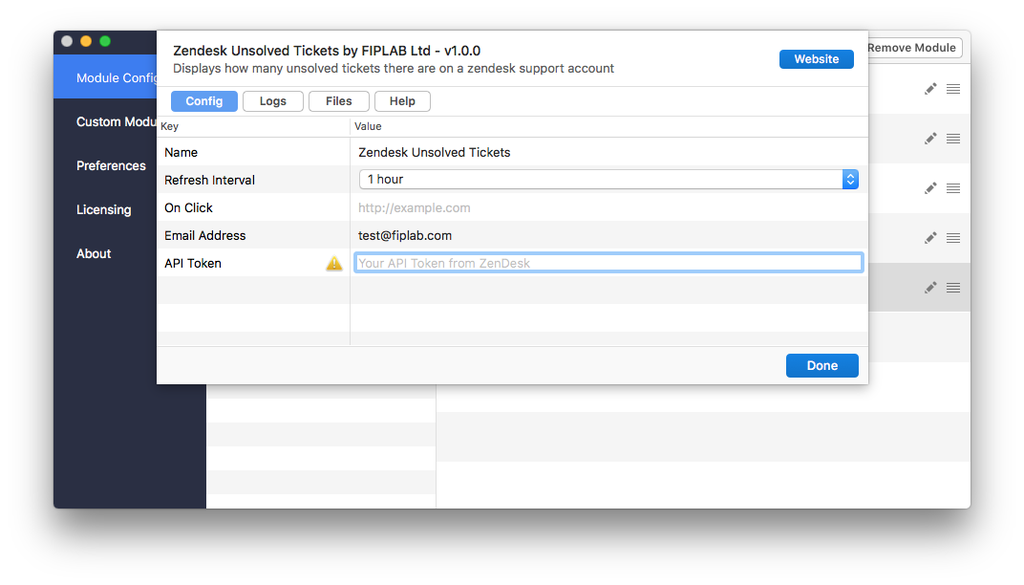

**Success** — You’re All Set!

## Common Errors

Invalid API Token. Please verify your email address and API Token then try again.

The API Token or Email entered invalid or revoked. Verify your information then try again, if you continue to get this error follow the steps above to regenerate an API Token.

Invalid response from server

There was an error while connecting to the Zendesk API. Please verify your internet connection then try again.